# Movies personal project

Ian

2022-11-02

## Looking at IMDb Movies and Genres dataset

Being a movie junkie, I have a personal interest in exploring this dataset. Some possible points of interests can be

- Big directors and their genres
- Have Ratings changed over time
- Is there an interaction between main and side genre that gives higher Ratings
- Censorship over time
- Relationships between actors and directors

Potential modelling

- Can we predict ratings given variables
  - Need to first check for relationships

Let us do a cursory check on the data

```r
kable(sapply(movies, typeof)) %>% kable_styling()
```

|  | x |
| --- | --- |
| Movie_Title | character |
| Year | integer |
| Director | character |
| Actors | character |
| Rating | double |
| Runtime.Mins. | integer |
| Censor | character |
| Total_Gross | character |
| main_genre | character |
| side_genre | character |

We have a few columns: Movie_Title, Year, Director, Actors, Rating, Runtime.Mins., Censor, Total_Gross, main_genre, side_genre, and we have a total of 5562 rows of data (i.e. 5562 movies)

We can see that something looks off - for example, total_gross should not be a character, lets take a look at a sample: Gross Unkown, $534.86M, $377.85M, $292.58M, $342.55M, $315.54M - we can already see that it is probably made into a string due to presence of “Gross Unknown”: Gross Unkown, $534.86M, $377.85M, $292.58M, $342.55M, $315.54M, $171.48M, $290.48M, $204.84M, $322.74M - hence we need to clean this up

We may also want to change some columns to factor, such as censor and genres

```r
# sum(movies$Total_Gross == "Gross Unkown")

## replace "Gross Unkown" with NA
movies[movies$Total_Gross == "Gross Unkown",]$Total_Gross = NA

## remove the "$" and "M" prefix and suffix from the non-problematic entries
library(stringr)
movies[!is.na(movies$Total_Gross),]$Total_Gross <-
  str_sub(movies[!is.na(movies$Total_Gross),]$Total_Gross, 2, -2)

## make numeric
movies$Total_Gross <-as.numeric(movies$Total_Gross)

## set Censorship, Main genre to factor
movies$Censor <- as.factor(movies$Censor)
movies$main_genre <- as.factor(movies$main_genre)
```

## Univariate analysis

To explore the data, we can look at some columns of interest one by one

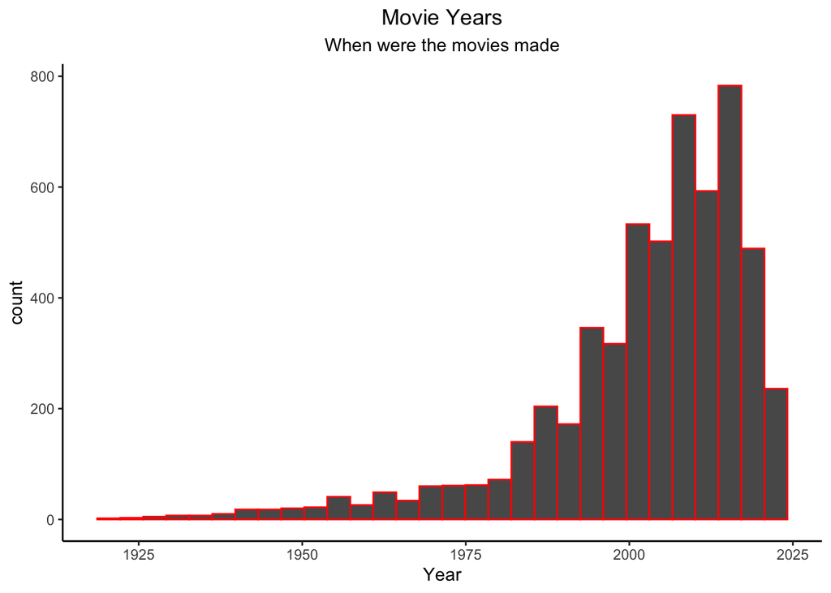

```r
movies %>% ggplot(aes(x = Year)) + geom_histogram(col = "red") +
  theme_classic() + ## for a nicer background
  ggtitle(label = "Movie Years", subtitle = "When were the movies made") +
  theme(plot.title = element_text(hjust = .5),
        plot.subtitle = element_text(hjust = .5))
```

The years for the movies in this dataset are left skewed – there are fewer movies made in the past than closer to the present. - The range of years are 1920, 2022, representing more than 100 years of movies

```r
top10directors <- movies %>% select(Director) %>% count(Director) %>% arrange(desc(n)) %>%
  top_n(n = 10)
```

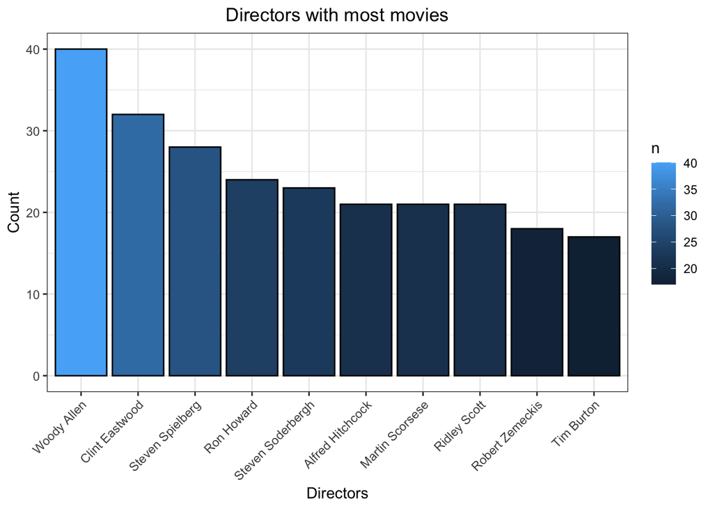

```r
## reorder the x in terms of -n in order to arrange bars in descending order
ggplot(top10directors, aes(x = reorder(Director, -n), y = n, fill = n)) +
  theme_bw() +
  geom_bar(stat = "identity", color = "black")+
  labs(title = "Directors with most movies",
       x = "Directors",
       y = "Count")+
  theme(axis.text.x = element_text(angle = 45, hjust = 1),
        plot.title = element_text(hjust = .5))  ## more visible tick markets for x axis
```

```r
## vectors of all actors in the dataset
actorlist <- unlist(strsplit(movies$Actors, ",")) ## split according to commas
movies$Actors <- strsplit(movies$Actors, ",")

movies$Actors <- str_squish(movies$Actors) ## remove whitespace from front

## get 20 biggest actors in terms of number of movies
top20actorstable <- sort(table(Actors = actorlist), decreasing = T)[1:20]

## one hot encoding
top20actorsnames <- names(top20actorstable)

movies$bigactor <- NA

for (i in nrow(movies)){
  listactors <- unlist(movies[i,]$Actors)
  if (any(is.element(listactors, top20actorsnames))){
    movies[i,]$bigactor <- 1
  }
  else {movies[i,]$bigactor <- 0}
}
```

| Actors | Freq |
| --- | --- |
| Nicolas Cage | 40 |
| Tom Hanks | 40 |
| Robert De Niro | 39 |
| Samuel L. Jackson | 36 |
| Adam Sandler | 35 |
| Johnny Depp | 34 |
| Sylvester Stallone | 34 |
| Clint Eastwood | 32 |
| Denzel Washington | 32 |
| Mel Gibson | 32 |
| Tom Cruise | 32 |
| Bruce Willis | 30 |
| Morgan Freeman | 28 |
| Willem Dafoe | 28 |
| Dwayne Johnson | 27 |
| Keanu Reeves | 27 |
| Woody Harrelson | 26 |
| Arnold Schwarzenegger | 26 |
| Kevin Costner | 26 |
| Mark Wahlberg | 26 |

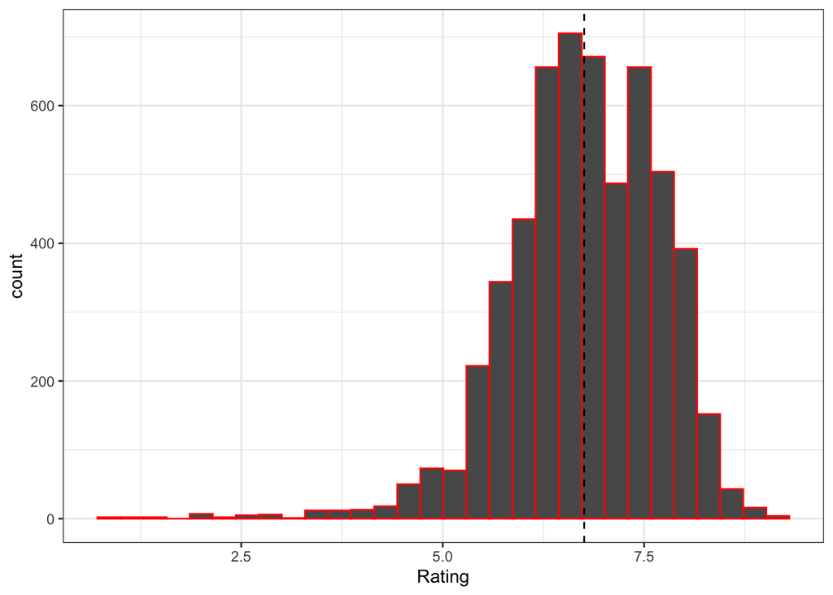

```r
movies %>% ggplot(aes(Rating)) + geom_histogram(col = "red") +
  theme_bw() +
  geom_vline(xintercept = mean(movies$Rating), linetype = "dashed")
```

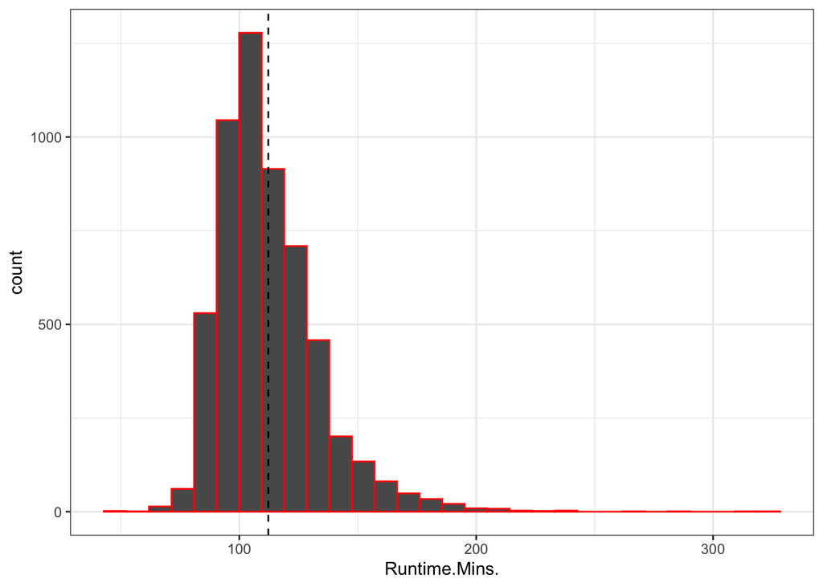

```r
movies %>% ggplot(aes(Runtime.Mins.)) + geom_histogram(col = "red") +
  theme_bw() +
  geom_vline(xintercept = mean(movies$Runtime.Mins.), linetype = "dashed")
```

Very right skewed movie durations, with most centering around low 100 minutes.

- Range of values: there are obviously outliers, 45, 321, with the highest at 321, 5.35 hours of movies, which is very long!
- The movie(s) is(are) Gangs of Wasseypur, Novecento

```r
sum(is.na(movies$Total_Gross))
```

```
## [1] 861
```

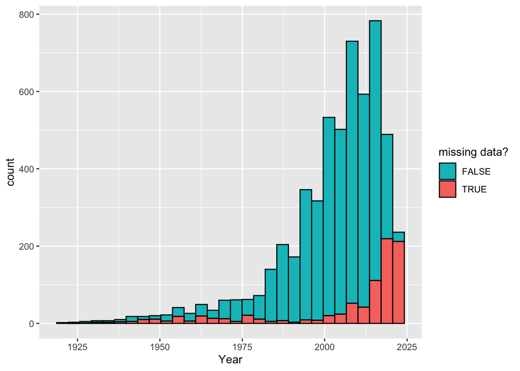

```r
missinggross_movies <- movies[is.na(movies$Total_Gross),]

## Investigate?

# in terms of Year
movies %>% ggplot(aes(x = Year)) + geom_histogram(aes(fill = is.na(Total_Gross)), col = "black") +
  scale_fill_manual(values = c("#00BFC4","#F8766D" ))+ ## flip the colours
  guides(fill = guide_legend(title = "missing data?"))
```

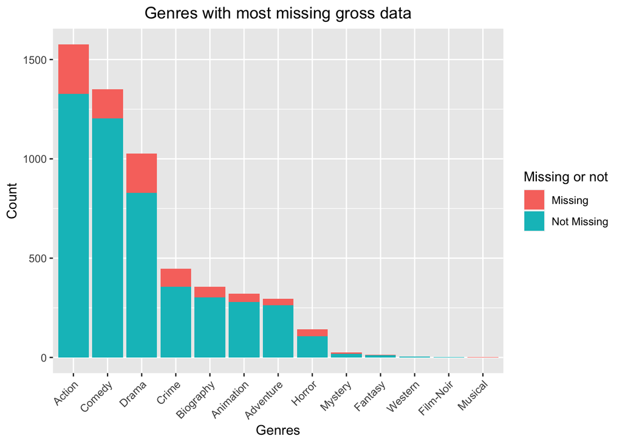

```r
moviesgenrecount <- movies %>% group_by(main_genre) %>% count()

## table of missing vs not missing genre (for plotting barplots)
table_plot <- movies %>% group_by(main_genre) %>% summarise(no_missing = sum(is.na(Total_Gross))) %>% left_join(moviesgenrecount) %>% mutate(no_not_missing = n - no_missing) %>% select(main_genre, no_missing, no_not_missing)
## make long table to be able to plot on ggplot barplot
longtable <- table_plot %>%pivot_longer(cols = c("no_missing", "no_not_missing"), names_to = "Missing or not",
                           values_to = "Count")

longtable %>% ggplot(aes(x = reorder(main_genre, -Count), y = Count, fill = `Missing or not`)) + geom_bar(stat = "identity", position = "stack") +labs(title = "Genres with most missing gross data",
       x = "Genres",
       y = "Count")+
  theme(axis.text.x = element_text(angle = 45, hjust = 1),
        plot.title = element_text(hjust = .5)) +
  scale_fill_discrete(labels = c("Missing", "Not Missing")) ## change legend labels in scale_fill_discrete
```

From the histogram, there is a skew towards modern day movies that are missing gross totals.

In terms of directors, 0 of the missing ones come from the top 10 directors.

Missing data for gross come somewhat proportionate from genres as well.

```r
kable(table(movies$Censor))
```

| Var1 | Freq |
| --- | --- |
| (Banned) | 8 |
| 12 | 1 |
| 12+ | 5 |
| 13 | 53 |
| 15+ | 18 |
| 16 | 71 |
| 18 | 136 |
| 18+ | 2 |
| 7 | 17 |
| A | 1101 |
| All | 5 |
| G | 9 |
| M/PG | 1 |
| NC-17 | 1 |
| Not Rated | 495 |
| PG | 120 |
| PG-13 | 405 |
| R | 926 |
| U | 1023 |
| U/A | 2 |
| UA | 1118 |
| UA 13+ | 12 |
| UA 16+ | 22 |
| UA 7+ | 7 |
| Unrated | 4 |